# 2_2_Classification_Logistic slides

## Logistic Classifier

We'll use a dataset of heights and weights of males and females

```python
dataset = pd.read_csv("heights_weights_genders.csv")
dataset.head()
```

|  | Gender | Weight | Height |
| --- | --- | --- | --- |
| 0 | Male | 73.847017 | 241.893563 |
| 1 | Male | 68.781904 | 162.310473 |
| 2 | Male | 74.110105 | 212.740856 |
| 3 | Male | 71.730978 | 220.042470 |
| 4 | Male | 69.881796 | 206.349801 |

```python
dataset.describe()
```

|  | Weight | Height |
| --- | --- | --- |
| count | 10000.000000 | 10000.000000 |
| mean | 66.367560 | 161.440357 |
| std | 3.847528 | 32.108439 |
| min | 54.263133 | 64.700127 |
| 25% | 63.505620 | 135.818051 |
| 50% | 66.318070 | 161.212928 |
| 75% | 69.174262 | 187.169525 |
| max | 78.998742 | 269.989699 |

First, we try a basic Logistic Regression:

- Split the data into a training and test (hold-out) set
- Train on the training set, and test for accuracy on the testing set

```python
from sklearn.model_selection import train_test_split
from sklearn.linear_model import LogisticRegression
from sklearn.metrics import accuracy_score
```

```python
Xlr, Xtestlr, ylr, ytestlr = train_test_split(dataset[['Height','Weight']].values,
                                              (dataset.Gender == "Male").values,random_state=5)
```

## Logistic Regression

Logistic regression predicts the probability of an outcome that can only have two values (i.e. a dichotomy). The prediction is based on the use of one or several predictors.

- A linear regression is not appropriate for predicting the value of a binary variable for two reasons:
- A linear regression will predict values outside the acceptable range (e.g. predicting probabilities outside the range 0 to 1)

Since the dichotomous experiments can only have one of two possible values for each experiment, the residuals will not be normally distributed about the predicted line. On the other hand, a logistic regression produces a logistic curve, which is limited to values between 0 and 1. Logistic regression is similar to a linear regression, but the curve is constructed using the natural logarithm of the “odds” of the target variable, rather than the probability. Moreover, the predictors do not have to be normally distributed or have equal variance in each group.

[figure not shown]

In the logistic regression the constant $(b_0)$ moves the curve left and right and the slope $(b_1)$ defines the steepness of the curve.

## Logistic Regression: The Math

The idea behind logistic regression is very simple. We want to draw a line in feature space that divides the '1' samples from the '0' samples, just like in the diagram above. In other words, we wish to find the "regression" line which divides the samples. Now, a line has the form $w_1 x_1 + w_2 x_2 + w_0 = 0$ in 2-dimensions. On one side of this line we have

$$w_1 x_1 + w_2 x_2 + w_0 \ge 0,$$

and on the other side we have

$$w_1 x_1 + w_2 x_2 + w_0 < 0.$$

Our classification rule then becomes:

\begin{eqnarray*} y = 1 &\mbox{if}& \v{w}\cdot\v{x} \ge 0\\ y = 0 &\mbox{if}& \v{w}\cdot\v{x} < 0 \end{eqnarray*}

where $\v{x}$ is the vector $\{1,x_1, x_2,...,x_n\}$ where we have also generalized to more than 2 features.

What hypotheses $h$ can we use to achieve this? One way to do so is to use the **sigmoid** function:

$$h(z) = \frac{1}{1 + e^{-z}}.$$

Notice that at $z=0$ this function has the value 0.5. If $z > 0$, $h > 0.5$ and as $z \to \infty$, $h \to 1$. If $z < 0$, $h < 0.5$ and as $z \to -\infty$, $h \to 0$. As long as we identify any value of $y > 0.5$ as 1, and any $y < 0.5$ as 0, we can achieve what we wished above.

This function is plotted below:

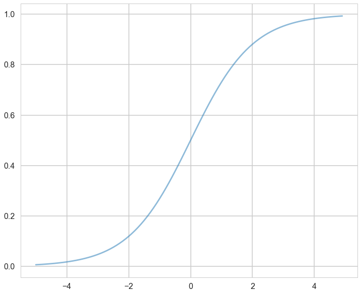

```python
h = lambda z: 1. / (1 + np.exp(-z))
zs=np.arange(-5, 5, 0.1)
plt.figure(figsize=(12,10))
plt.plot(zs, h(zs), alpha=0.5);
```

### Code Dictionary

| code | description |
| --- | --- |
| `LogisticRegression()` | Logistic regression Classification. |
| `lamba` | Quick define a function mapping without using def keyword. |
| `accuracy_score` | scikit learn function to compute the accuracy of prediction. |
| `GridSearchCV` | scikit learn function to perform cross validation and grid search of parameter array. |
| `.meshgrid()` | Make a pair combination of multiple array. |

```python
clf = LogisticRegression()
# Fit the model on the trainng data.
clf.fit(Xlr, ylr)
```

```
LogisticRegression(C=1.0, class_weight=None, dual=False, fit_intercept=True,
          intercept_scaling=1, max_iter=100, multi_class='ovr', n_jobs=1,
          penalty='l2', random_state=None, solver='liblinear', tol=0.0001,
          verbose=0, warm_start=False)
```

```python
print(accuracy_score(clf.predict(Xtestlr), ytestlr))
```

```
0.9252
```

```
Text(0,0.5,'Weight')
```

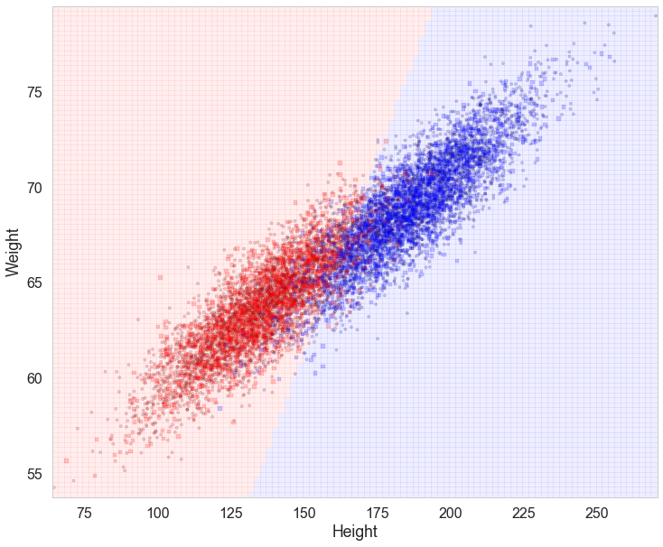

```python
plt.figure(figsize=(12,10)); ax = plt.gca()
points_plot(ax, Xlr, Xtestlr, ylr, ytestlr, clf, alpha=0.2)
plt.xlabel('Height')
plt.ylabel('Weight')
```

In the figure here showing the results of the logistic regression, we plot the actual labels of both the training(circles) and test(squares) samples. The 0's (females) are plotted in red, the 1's (males) in blue. We also show the classification boundary, a line (to the resolution of a grid square). Every sample on the red background side of the line will be classified female, and every sample on the blue side, male. Notice that most of the samples are classified well, but there are misclassified people on both sides, as evidenced by leakage of dots or squares of one color ontothe side of the other color. Both test and traing accuracy are about 92%.

### Tuning the Model

The model has some hyperparameters we can tune for hopefully better performance. For tuning the parameters of your model, you will use a mix of *cross-validation* and *grid search*. In Logistic Regression, the most important parameter to tune is the *regularization parameter* `C` (inverse of regularization strength). Note that the regularization parameter is not always part of the logistic regression model.

The regularization parameter is used to control for unlikely high regression coefficients, and in other cases can be used when data is sparse, as a method of feature selection.

You will now implement some code to perform model tuning and selecting the regularization parameter $C$.

We use the following `cv_score` function to perform K-fold cross-validation and apply a scoring function to each test fold. In this incarnation we use accuracy score as the default scoring function.

```python
from sklearn.model_selection import KFold

def cv_score(clf, x, y, score_func=accuracy_score):
    result = 0
    nfold = 5
    for train, test in KFold(nfold).split(x): # split data into train/test groups, 5 times
        clf.fit(x[train], y[train]) # fit
        result += score_func(clf.predict(x[test]), y[test]) # evaluate score function on held-out data
    return result / nfold # average
```

```python
clf = LogisticRegression()
score = cv_score(clf, Xlr, ylr)
print(score)
```

```
0.9170666666666666
```

### Evaluation Refresher I

**We** Implement the following search procedure to find a good model

- We are given a list of possible values of `C` below
- For each C:
  1. Create a logistic regression model with that value of C
  2. Find the average score for this model using the `cv_score` function **only on the training set** `(Xlr, ylr)`
- Pick the C with the highest average score

Our goal is to find the best model parameters based *only* on the training set, without showing the model test set at all (which is why the test set is also called a *hold-out* set).

```python
#the grid of parameters to search over
Cs = [0.001, 0.1, 1, 10, 100]

# your turn
from operator import itemgetter

scores = {}
for i, C_value in enumerate(Cs):
# with penalty=l2 the accuracy scores are too close to one another
# when re-running on same data, got different results, changed tol value until rerunning gave the same value
    clf = LogisticRegression(penalty='l1',C=C_value, tol=1e-18)
    scores[i] = cv_score(clf, Xlr, ylr)

sorted_scores = sorted(scores.items(), key=itemgetter(1))
print (sorted_scores)
best_score = Cs[sorted_scores[4][0]]
print('Highest average score of {} occured for C = {}'.format(sorted_scores[4][1],best_score))
```

```
[(4, 0.9141333333333334), (3, 0.9151999999999999), (2, 0.9156000000000001), (0, 0.9166666666666667), (1, 0.9170666666666666)]
Highest average score of 0.9170666666666666 occured for C = 0.1
```

### Evaluation Refresher II

Now We want to estimate how this model will predict on unseen data in the following way:

1. Use the C you obtained from the procedure earlier and train a Logistic Regression on the training data
2. Calculate the accuracy on the test data

We should notice that this particular value of `C` may or may not do as well as simply running the default model on a random train-test split.

- Do you think that's a problem?
- Why do we need to do this whole cross-validation and grid search stuff anyway?

```python
# using C = 0.1 train  on training data
clf = LogisticRegression(penalty='l1',C=0.1)
clf.fit(Xlr, ylr)
```

```
LogisticRegression(C=0.1, class_weight=None, dual=False, fit_intercept=True,
          intercept_scaling=1, max_iter=100, multi_class='ovr', n_jobs=1,
          penalty='l1', random_state=None, solver='liblinear', tol=0.0001,
          verbose=0, warm_start=False)
```

```python
# Now get score using test data
cv_score(clf, Xtestlr, ytestlr)
```

```
0.9228000000000002
```

The fact that the test run score may not be as good as the score on a random train-test run is not a problem. We would expect the score to be better on the training run than the test run as the regression model has been fit to the training data. The cross-validation process is going to allow you to find the "best" overall parameter value as opposed to the best value for a specific set of data.